# Technical_Report- Predictive Pricing Model

Rauhan Nazir

2/10/2022

## Introduction

The purpose of this project was to help a company in setting their price for their newly launched apartments in **Toronto**, Canada. This company operates and deals with small and mid-sized apartments hosting 2-6 guests. The goal was achieved through building multiple predictive models based on the data we extracted from [Inside Airbnb](http://insideairbnb.com/get-the-data.html). There were 4 models that were created, namely OLS Linear Regression, Random Forest, Cart & GBM, and their performance was evaluated based on their RMSE, and the final price recommendation made was based on the model with the lowest RMSE. These models consider variables like property type, neighbourhoods, and whether they have certain amenities. The variables that were fed into the machine learning algorithms were shortlisted from the most complex model through LASSO, where it removed the variables with zero coefficients. This will be explained further in the report.

## Data Cleaning and Data Preparation

The data set that I initially downloaded from the Airbnb website contained **15,435** listings, however it had to be cleaned and filtered down to only the listings that were relevant and similar to the apartments that my company was about to launch, making sure that the data we used in our models was a result of conscious decisions made, ensuring that we were not feeding any irrelevant data into the models that made us compromise on the quality and accuracy of the models. Hence, a lot of time and detailed thought process was spent on the data cleaning and data preparation. But before performing any data cleaning, I saved the loaded raw data as an RDS file for easy retrieval.

There was only one listing that was scraped on the 9th of January, so I just dropped it. After that I started performing basic data checks and the first one was to check if data had rows with only NAs and duplicate values, as it made no sense to keep them. However, I did not find any such rows. Another check that I performed was to see how many columns had more than 50% NA values, to figure out which variables needed more attention, and drop them especially if they are not important predictors. There were 3 variables that had all the values as NAs, including the “bathrooms”, so I just dropped them right away. However, Bathroom is an important feature for predicting the apartment price, so I extracted that information as a numeric variable from a column named bathroom_text. I also dropped all the other irrelevant variables at this stage as well. The listings in the data set contained all type of listings including the ones that were not apartments or were not similar to apartments, like private suits, so I filtered the data down to the ones that were relevant, namely, “Entire loft”, “Entire serviced apartment”, “Entire home/apt” and “Entire condominium (condo)”. Even from those listings I filtered down to the ones that accommodated 2 to 6 people, as these were the only ones that matched our criteria.

Moving further, I cleaned the important variables to get them in a form that can be fed into the models. Firstly, using the gsub function, I removed the percentage signs from the percentage columns such as the host acceptance rate and the host response rate. The dollar sign was also removed from the price variable, which is our target variable. I also converted the True/False values into 1s and 0s (Binary variable). Another important factor while valuing the property is the kind of amenities an apartment comes with. In the initial data set, the amenities were included in one variable as a list, and for us to be able to include all those features in the models, it was necessary to extract all of them into separate dummy variables, and for that I had to go through extensive data cleaning and preparation. There were a lot of amenities, even those that did not make much of a difference. So, after extracting all the amenities, I dropped the ones that had minimal and no impact and clubbed those which were quite similar to each other. For instance, TV and Netflix, and children, crib, and baby were clubbed into one separate dummy variable. For this process, the domain knowledge was extremely important, and I had to go through extensive research. After that I changed the values in the property type to make them cleaner and remove the redundant words such as “Entire condominium (condo)” was changed to “Condo”. There was no point including variables that had no variance in them, as they would not help predicting the price at all, one example was the room type variable. The filtered data had only one type of room, so I dropped that variable.

A crucial thing to consider before making the predictive models was to ensure that the variables had the desired structure, for instance converting variables into factors that were supposed to be taken as factors, and the numeric variables were actually stored as numeric variables. One important example of the factor variable was the neighbourhood_cleansed, as generally, based on the neighbourhood the apartment is located, the prices for the apartments vary significantly. So, for each of the neighbourhood present in the data set, a different level was created. As mentioned earlier, the number of bathrooms can make a difference in the property value and there were a couple of conscious decisions that I made while cleaning this variable. The data set included bathroom values in decimals as well, that do not make much sense and for easier and clearer interpretation, I rounded them to whole number. For instance, 1.5, 2.5 and 3.5 bathrooms were just considered to be 2,3 and 4 respectively, the rationale behind this was that I considered the half bathroom as a whole bathroom as well.

For all the variables that I converted to factors, percentages, numeric and dummy, I put a prefix of f, p, n and d respectively so that I can easily recognize and then only kept those, apart form the target variable, as these were the final variables that were going to be used to make the predictive models. One important decision that I had to make was that how the missing values were going to be dealt with. There was a different approach taken for different variable, based on my domain knowledge. For instance, for the variable missing bed, I used the variable, number of accommodates, to apply a sense check. Where there were 3 people accommodated, I included number of beds as 2, and this is the ratio that was applied throughout.

I then checked the distribution of our target variable (Price), to see if there was a need to transform it my taking a log of it to make it more normally distributed. However, upon inquiry I found out that there was no need for taking the log and absolute values resembled more to that of a normal distribution. I also filtered down to the apartments that were priced at 350 dollars or less, since it was very rare for the apartments to be priced above that and since our apartments are going to small or mid-sized, there was no need to include the ones above 350 dollars. Finally, for the cleaning and preparation phase I pooled values within certain variables, which did not have a significant difference between their mean values, before converting them as factors.

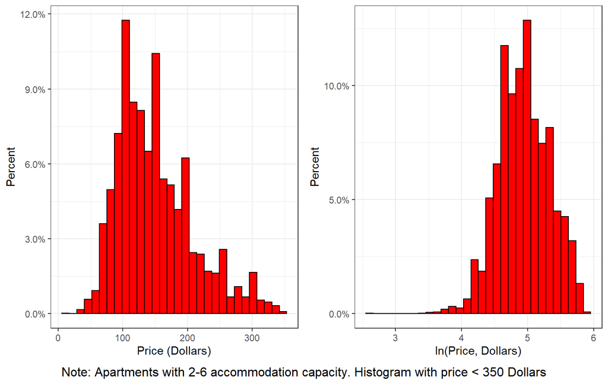

## Building Predictive Models

After all the data cleaning and data preparation, following are the variables that were used in the models that were created to predict the price of an apartment:

- *Dummies*: Binary variables consisting of all the amenities that are being offered by host.
- *Size variables*: This includes numeric variable like number of beds, number of baths, number of people it accommodates, and minimum nights.
- *Factor variables*: For each Neighbourhood, type of property, including flag and factorized variable of size variables.
- *Reviews variables*: Review score rating and the number of reviews the apartment gets each month.
- *Host variables*: Dummies for host verification and if they a super host or not.
- *Interaction Terms*

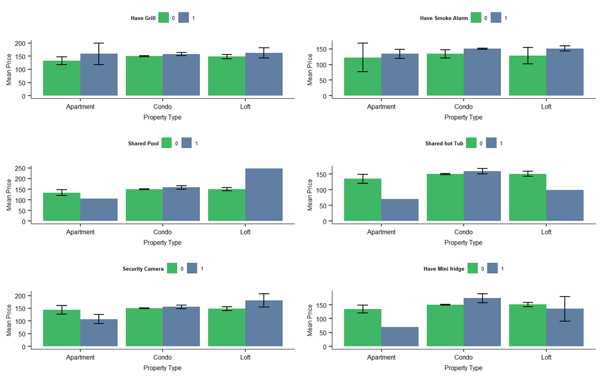

## Cross Validation & Holdout

After all the data cleaning there were 3685 listings left. Of these listings, 20% were randomly selected as a holdout set (test set), while the rest were used as a training set. The training set underwent 5 test fold cross validation, allowing our models to perform more efficiently and provide the coefficients with least amount of overfitting. The result of these cross-validated RMSEs were used to then evaluate the model performance and was used as primary criteria to select the best model.

## OLS Predictive Models

**Versions of the Airbnb Apartment Price Prediction Models**

| Model | Predictor Variables |
| --- | --- |
| M1 | ~ n_accommodates |
| M2 | ~ n_accommodates+ basic_lev |
| M3 | ~ n_accommodates+ basic_lev + basic_add + reviews + host + dummies |
| M4 | ~ n_accommodates+ basic_lev + basic_add + reviews + host + dummies + interaction |

There were 4 models that were run with OLS, with each model getting more complex in terms of number of coefficients. Model 1 only had a single predictor, while model 4 had 330. These models were evaluated based on RMSE and BIC. Even though model 4 had the highest R-square, it also had the highest RMSEs and BIC, meaning that the model was being penalized for over-fitting. If we consider everything, model 3, with 146 coefficients, performed the best, as it had the lowest Test RMSE, and a relatively higher R-square compared to the first 2 models. All these regressions were run based on our training and test sets via 5-fold cross validations.

## Random Forest

There were two types of Random Forests created. One where there were tuning parameters provided and the second was the one which had auto-tuning. It is a supervised learning algorithm where the end result is a combination of different trees, that were trained with the bagging method. So, the end result is essentially a result of averages of numerous trees, meaning that it is quite accurate of the actual representation. This was cross validated as well. The tuning parameters that we provided for the first one was as following:

-Number of variables (mtry) were from 8 to 12 -Minimum number of observation (min. nodes) were 5,10,15

This model performed the best when mtry was equal to 12 and the min node size equals to 5, as this was the one with the lowest RMSE.

Random Forest RMSE by tuning parameters

| nodes | 8 | 10 | 12 |
| --- | --- | --- | --- |
| 5 | 52.68208 | 52.22723 | 51.80691 |
| 10 | 52.84266 | 52.31022 | 52.06743 |
| 15 | 52.95534 | 52.52971 | 52.14600 |

For both RF methods, variable importance graphs were constructed that showed which variables were the most important in predicting the prices. First these were done without any grouping, and during the second iteration some of the variables were grouped together, such as all the amenities’ dummies were grouped together. For the one where parameters were provided, the top three predictors were amenities, property type and reviews an apartment got. Same was the cases for the Auto-tuning RF. The difference between both RMSEs was minimal, however auto tuning one had a slightly lower one.

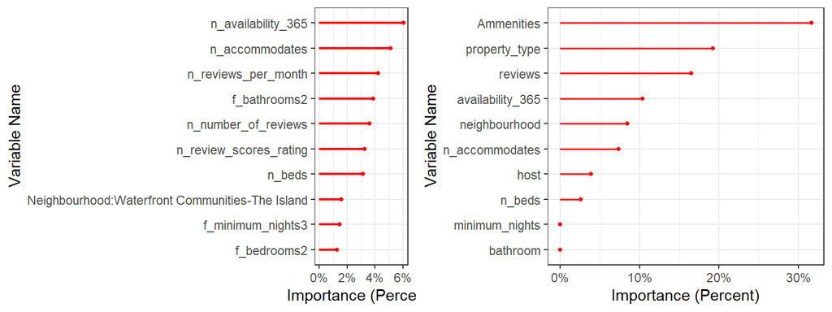

## CART with Pruning

How CART with pruning works is that the training data is split randomly into several folds for instance 10, after which the pruning level is selected. 9 folds are used for creation of 9 pruned trees and an error is estimated on the last fold. The second step is repeated until all the pruning levels are used. The smallest error is found, and the pruning level assigned to it is used. Until pruning level is reached, all terminal nodes in the lowest tree level are removed and decision class is assigned to parent node. Decision value is equal to class with higher number of cases covered by node. Even though it’s RMSE was slightly higher than that of Random Forest, there is a high possibility of overfitting in the model.

## GBM

Gradient boosting machine is a model which creates trees, and, with each iteration, it improves upon the previous tree. Hence, in principle this method is better than CART. In our predictive models, this was also the case in terms of the RMSEs of the models. This performed better than both the OLS and CART.

Below is the table the shows the RMSEs of all the models.

Based on these results, Random Forest with Auto Tuning was shortlisted, and based on this model Partial dependence plots were created, to provide insights and interpretable results

## Partial Dependence

Based on the results from the variable importance plot we analyse the shape of association between average y and important x variables, condition on the rest (BEKES, 2022). So, it keeps everything else other than the predictive variable we want to see association of with the target variable. We created two such graphs, one with the property type and the second one with the number of people it accommodates. In the property type, Lofts were the ones which were priced the highest while for the number of people it accommodates, price went up when the persons accommodated increased.

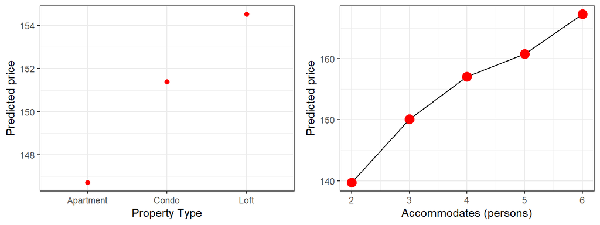

## Sub sample

To further check our RF performance, we run sub sample on three x variables as shown in the figure below.

```r
result_3%>% kbl(caption = "Performance across sub-sample", escape = FALSE) %>%
  kable_classic(full_width = F, html_font = "Cambria") %>%
  kable_styling( position = "center")
```

Performance across sub-sample

| Var.1 | RMSE | Mean.price | RMSE.price |
| --- | --- | --- | --- |
| Apartment size | NA | NA | NA |
| large apt | 52.96220 | 164.2159 | 0.3225157 |
| small apt | 45.94884 | 133.2559 | 0.3448165 |
| Beds | NA | NA | NA |
| 1 | 45.52181 | 134.4846 | 0.3384909 |
| 2 | 51.42381 | 154.8624 | 0.3320613 |
| 3 | 55.13702 | 164.4722 | 0.3352360 |
| 4 | 43.37636 | 197.3750 | 0.2197662 |
| Property Type | NA | NA | NA |
| Apartment | 27.63419 | 138.2667 | 0.1998615 |
| Condo | 49.15667 | 146.0952 | 0.3364700 |
| Loft | 52.77870 | 154.2400 | 0.3421856 |

## Conclusion

Ranking of Models CV RSME

|  | CV RMSE |
| --- | --- |
| OLS | 53.60633 |
| CART | 55.22658 |
| Random forest 1: Tuning provided | 51.80691 |
| Random forest 2: Auto Tuning | 50.78555 |
| GBM | 52.19982 |